# Project 2: Data Mining, Classification, Prediction

SDS322E

# Mining, Classification, Prediction

## Shaojie Hou, sh49854

### Introduction

In this project, I’m going to use different clinical features of human body to predict heart disease event. There will be different clinical data of people and the results of if they have heart disease in the “heart.csv”. I will explore the relationship between those clinical data and the final results of their heart health condition. The data is obtained from Kaggle and updated within the most recent year.

```r
library(tidyverse)
library(dplyr)
library(factoextra)
library(GGally)
heart = read.csv(("heart.csv"))
```

### Cluster Analysis

```r
library(cluster)

clust_dat <- heart %>%
    dplyr::select(Age, RestingBP, Cholesterol, HeartDisease)

sil_width <- vector()
for (i in 2:10) {
    kms <- kmeans(na.omit(clust_dat), centers = i)
    sil <- silhouette(kms$cluster, dist(clust_dat))
    sil_width[i] <- mean(sil[, 3])
}

sil_width
```

```
##  [1]        NA 0.7339147 0.5399120 0.5270493 0.4524024 0.4308928 0.3817292
##  [8] 0.3936296 0.3844064 0.3097939
```

```r
heart_num <- heart %>%
    select_if(is.numeric) %>%
    mutate(HeartDisease = as.character(HeartDisease))
heart_num
```

```
##    Age RestingBP Cholesterol FastingBS MaxHR Oldpeak HeartDisease
## 1   40       140         289         0   172     0.0            0
## 2   49       160         180         0   156     1.0            1
## 3   37       130         283         0    98     0.0            0
## 4   48       138         214         0   108     1.5            1
## 5   54       150         195         0   122     0.0            0
## 6   39       120         339         0   170     0.0            0
## 7   45       130         237         0   170     0.0            0
## 8   54       110         208         0   142     0.0            0
## 9   37       140         207         0   130     1.5            1
## 10  48       120         284         0   120     0.0            0
## 11  37       130         211         0   142     0.0            0
## 12  58       136         164         0    99     2.0            1
## 13  39       120         204         0   145     0.0            0
## 14  49       140         234         0   140     1.0            1
##  [ reached 'max' / getOption("max.print") -- omitted 904 rows ]
```

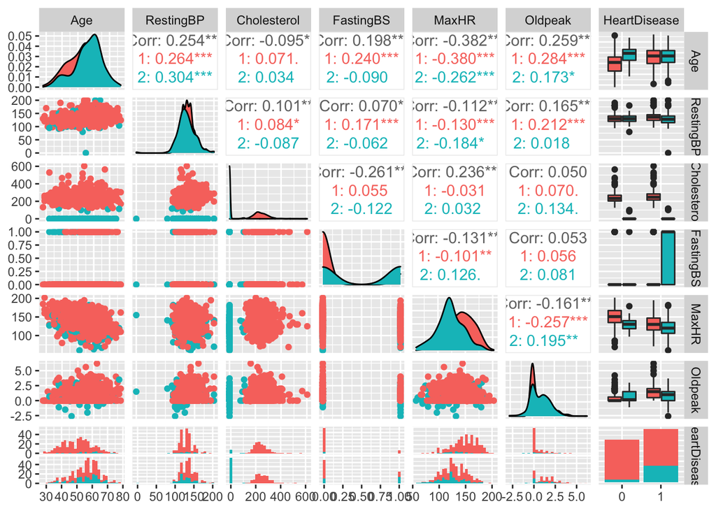

```r
heart_pam <- clust_dat %>%
    pam(k = 2)

heart_num %>%
    mutate(cluster = as.factor(heart_pam$clustering)) %>%
    ggpairs(columns = 1:7, aes(color = cluster))
```

### Dimensionality Reduction with PCA

```r
# PCA code here
heart_num <- heart %>%
    select_if(is.numeric) %>%
    scale
heart_pca <- princomp(heart_num, cor = T, scale = T)

summary(heart_pca, loadings = T)
```

```
## Importance of components:
##                           Comp.1    Comp.2    Comp.3    Comp.4     Comp.5
## Standard deviation     1.4916423 1.1299103 0.9668541 0.9253939 0.81936784
## Proportion of Variance 0.3178567 0.1823853 0.1335438 0.1223363 0.09590909
## Cumulative Proportion  0.3178567 0.5002420 0.6337858 0.7561221 0.85203122
##                            Comp.6     Comp.7
## Standard deviation     0.76978252 0.66574497
## Proportion of Variance 0.08465216 0.06331662
## Cumulative Proportion  0.93668338 1.00000000
##
## Loadings:
##              Comp.1 Comp.2 Comp.3 Comp.4 Comp.5 Comp.6 Comp.7
## Age           0.449  0.187  0.256  0.280  0.552  0.475  0.298
## RestingBP     0.224  0.501  0.612        -0.566
## Cholesterol  -0.252  0.644                0.474 -0.531
## FastingBS     0.313 -0.357  0.406 -0.626  0.325 -0.235 -0.237
## MaxHR        -0.454               -0.600         0.462  0.456
## Oldpeak       0.354  0.402 -0.514 -0.355         0.329 -0.461
## HeartDisease  0.505        -0.355 -0.178 -0.203 -0.338  0.656
```

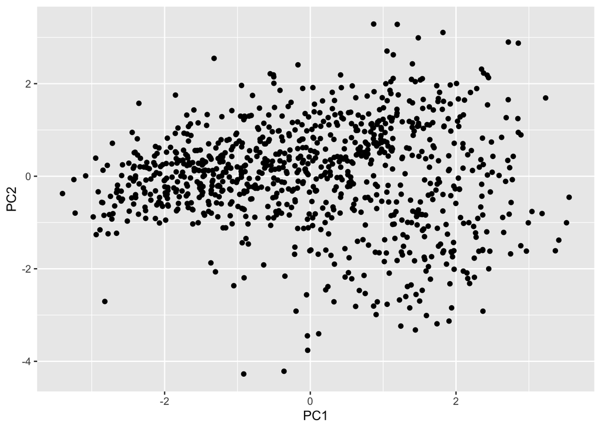

```r
heartdf <- data.frame(PC1 = heart_pca$scores[, 1], PC2 = heart_pca$scores[,
    2])
ggplot(heartdf, aes(PC1, PC2)) + geom_point()
```

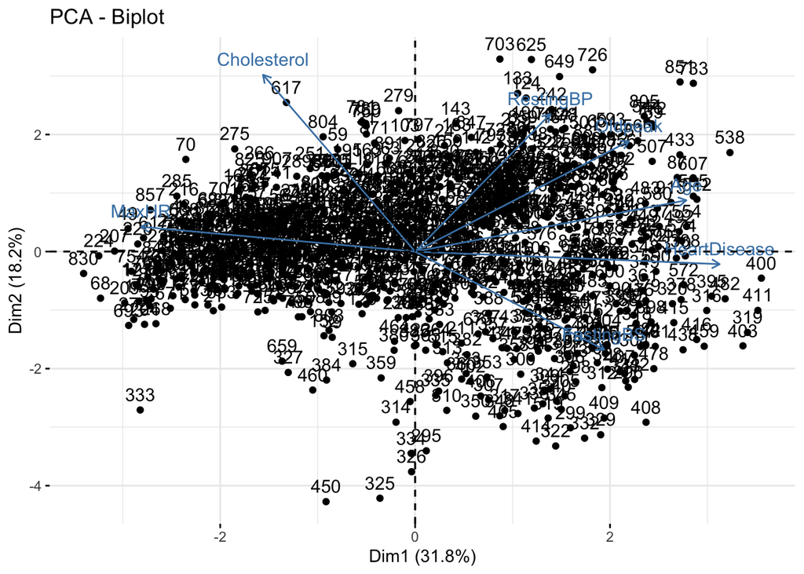

```r
fviz_pca_biplot(heart_pca)
```

### Linear Classifier

```r
y <- heart$HeartDisease
heart
```

```
##   Age Sex ChestPainType RestingBP Cholesterol FastingBS RestingECG MaxHR
## 1  40   M           ATA       140         289         0     Normal   172
## 2  49   F           NAP       160         180         0     Normal   156
## 3  37   M           ATA       130         283         0         ST    98
## 4  48   F           ASY       138         214         0     Normal   108
## 5  54   M           NAP       150         195         0     Normal   122
## 6  39   M           NAP       120         339         0     Normal   170
## 7  45   F           ATA       130         237         0     Normal   170
## 8  54   M           ATA       110         208         0     Normal   142
##   ExerciseAngina Oldpeak ST_Slope HeartDisease
## 1              N     0.0       Up            0
## 2              N     1.0     Flat            1
## 3              N     0.0       Up            0
## 4              Y     1.5     Flat            1
## 5              N     0.0       Up            0
## 6              N     0.0       Up            0
## 7              N     0.0       Up            0
## 8              N     0.0       Up            0
##  [ reached 'max' / getOption("max.print") -- omitted 910 rows ]
```

```r
heart_num <- heart %>%
    select_if(is.numeric)
fit <- lm(HeartDisease ~ ., data = heart_num, family = "binomial")
fit
```

```
##
## Call:
## lm(formula = HeartDisease ~ ., data = heart_num, family = "binomial")
##
## Coefficients:
## (Intercept)          Age    RestingBP  Cholesterol    FastingBS        MaxHR
##    1.070328     0.002011     0.000332    -0.000633     0.197884    -0.005351
##     Oldpeak
##    0.161433
```

```r
score <- predict(fit, type = "response")
score %>%
    round(3)
```

[output not shown]

```r
class_diag(score, truth = heart$HeartDisease, positive = 1)
```

```
##            acc   sens   spec    ppv     f1     ba    auc
## Metrics 0.7767 0.7913 0.7585 0.8024 0.7968 0.7749 0.8455
```

**The AUC is 0.8455 which is between 0.8 and 0.9 and it is good based on Rules of thumb for AUC.**

```r
# cross-validation of linear classifier here
set.seed(1234)
# split the dataset in two random parts
one <- heart_num %>%
    sample_frac(0.5)
two <- heart_num %>%
    anti_join(one)
fit <- lm(HeartDisease ~ ., data = one, family = "binomial")
probs1 <- predict(fit, newdata = two, type = "response")

diags1 <- class_diag(probs1, two$HeartDisease, positive = 1)
fit <- lm(HeartDisease ~ ., data = two, family = "binomial")
probs2 <- predict(fit, newdata = one, type = "response")
diags2 <- class_diag(probs2, one$HeartDisease, positive = 1)
diags <- rbind(diags1, diags2)
diags
```

```
##             acc   sens   spec    ppv     f1     ba    auc
## Metrics  0.7707 0.7615 0.7828 0.8216 0.7904 0.7722 0.8395
## Metrics1 0.7647 0.8097 0.7123 0.7663 0.7874 0.7610 0.8396
```

```r
summarize_all(diags, mean)
```

```
##      acc   sens    spec     ppv     f1     ba     auc
## 1 0.7677 0.7856 0.74755 0.79395 0.7889 0.7666 0.83955
```

**The AUC after cross validation is 0.83955 which is between 0.8 and 0.9 and it is good based on the Rules of thumb for AUC. Since model does similar performance in CV, there is not sign of overfitting.**

### Non-Parametric Classifier

```r
library(caret)
# non-parametric classifier code here
knn_fit <- knn3(factor(HeartDisease == 1, levels = c("TRUE",
    "FALSE")) ~ ., data = heart_num, k = 5)
knn_fit
```

```
## 5-nearest neighbor model
## Training set outcome distribution:
##
##  TRUE FALSE
##   508   410
```

```r
y_hat_knn <- predict(knn_fit, heart_num)
y_hat_knn
```

```
##             TRUE     FALSE
##   [1,] 0.4000000 0.6000000
##   [2,] 0.2000000 0.8000000
##   [3,] 0.8000000 0.2000000
##   [4,] 1.0000000 0.0000000
##   [5,] 0.2000000 0.8000000
##   [6,] 0.0000000 1.0000000
##   [7,] 0.0000000 1.0000000
##   [8,] 0.0000000 1.0000000
##   [9,] 0.2000000 0.8000000
##  [10,] 0.6000000 0.4000000
##  [11,] 0.0000000 1.0000000
##  [12,] 0.6000000 0.4000000
##  [13,] 0.0000000 1.0000000
##  [14,] 0.4000000 0.6000000
```

[output cut: 37 more lines]

```r
data.frame(y_hat_knn, names = rownames(heart)) %>%
    arrange(names)
```

```
##        TRUE.    FALSE. names
## 1  0.4000000 0.6000000     1
## 2  0.6000000 0.4000000    10
## 3  0.2000000 0.8000000   100
## 4  0.8000000 0.2000000   101
## 5  0.4000000 0.6000000   102
## 6  0.8000000 0.2000000   103
## 7  0.6000000 0.4000000   104
## 8  0.4000000 0.6000000   105
## 9  0.8000000 0.2000000   106
## 10 0.4000000 0.6000000   107
## 11 0.4000000 0.6000000   108
## 12 0.6000000 0.4000000   109
## 13 0.0000000 1.0000000    11
## 14 0.6000000 0.4000000   110
```

[output cut: 20 more lines]

```r
class_diag(y_hat_knn[, 1], heart_num$HeartDisease == 1, positive = 1)
```

```
##            acc  sens   spec    ppv     f1     ba    auc
## Metrics 0.7843 0.811 0.7512 0.8016 0.8063 0.7811 0.8687
```

```r
table(truth = factor(heart_num$HeartDisease == 1, levels = c("TRUE",
    "FALSE")), prediction = factor(y_hat_knn[, 1] > 0.5, levels = c("TRUE",
    "FALSE")))
```

```
##        prediction
## truth   TRUE FALSE
##   TRUE   412    96
##   FALSE  102   308
```

```r
# cross-validation of np classifier here
set.seed(1234)
k = 10
data <- heart_num[sample(nrow(heart_num)), ]
folds <- cut(seq(1:nrow(heart_num)), breaks = k, labels = F)
diags <- NULL
for (i in 1:k) {

    train <- data[folds != i, ]
    test <- data[folds == i, ]
    truth <- test$HeartDisease
    ## Train model on training set (all but fold i)
    fit <- knn3(HeartDisease ~ ., data = train)

    probs <- predict(fit, newdata = test)[, 2]

    diags <- rbind(diags, class_diag(probs, truth, positive = 1))
}
diags
```

```
##             acc   sens   spec    ppv     f1     ba    auc
## Metrics  0.6413 0.6939 0.5814 0.6538 0.6733 0.6376 0.6680
## Metrics1 0.7500 0.7500 0.7500 0.8235 0.7850 0.7500 0.7837
## Metrics2 0.7065 0.7500 0.6591 0.7059 0.7273 0.7045 0.7550
## Metrics3 0.7363 0.7857 0.6939 0.6875 0.7333 0.7398 0.8338
## Metrics4 0.6304 0.6923 0.5500 0.6667 0.6792 0.6212 0.6303
## Metrics5 0.7826 0.8475 0.6667 0.8197 0.8333 0.7571 0.8413
## Metrics6 0.6813 0.7755 0.5714 0.6786 0.7238 0.6735 0.7187
## Metrics7 0.6848 0.7358 0.6154 0.7222 0.7290 0.6756 0.7054
## Metrics8 0.7717 0.8400 0.6905 0.7636 0.8000 0.7652 0.8155
## Metrics9 0.6196 0.5600 0.6905 0.6829 0.6154 0.6252 0.6714
```

```r
summarize_all(diags, mean)
```

```
##       acc    sens    spec     ppv      f1      ba     auc
## 1 0.70045 0.74307 0.64689 0.72044 0.72996 0.69497 0.74231
```

**The AUC after cross validation is 0.74231 which is between 0.7 and 0.8 and it is fair based on the Rules of thumb for AUC. Since model does much more poorly in CV, there is sign of overfitting.Th nonparametric model compared with the linear model in its cross-validation performs a worse performance.**

### Regression/Numeric Prediction

```r
# regression model code here
fit <- lm(HeartDisease ~ ., data = heart_num)
yhat <- predict(fit)
yhat
```

[output not shown]

```r
mean((heart_num$HeartDisease - yhat)^2)
```

```
## [1] 0.1633737
```

```r
set.seed(1234)
k = 5
data <- heart_num[sample(nrow(heart_num)), ]
folds <- cut(seq(1:nrow(heart_num)), breaks = k, labels = F)
diags <- NULL
for (i in 1:k) {
    train <- data[folds != i, ]
    test <- data[folds == i, ]

    fit <- lm(HeartDisease ~ ., data = train)

    yhat <- predict(fit, newdata = test)

    diags <- mean((test$HeartDisease - yhat)^2)
}


MSE <- mean(diags)
MSE
```

```
## [1] 0.170617
```

**Since the MSE is similar:0.1633737 and 0.170617. There is not sign of overfitting.**

### Python

```r
library(reticulate)
```

```python
import numpy as np
import matplotlib.pyplot as plt
heart_df = r.heart
x = heart_df['Age']
y = heart_df['Cholesterol']
plt.scatter(x,y, color="blue", alpha=.5)
plt.xlim(25, 80)
```

```
## (25.0, 80.0)
```

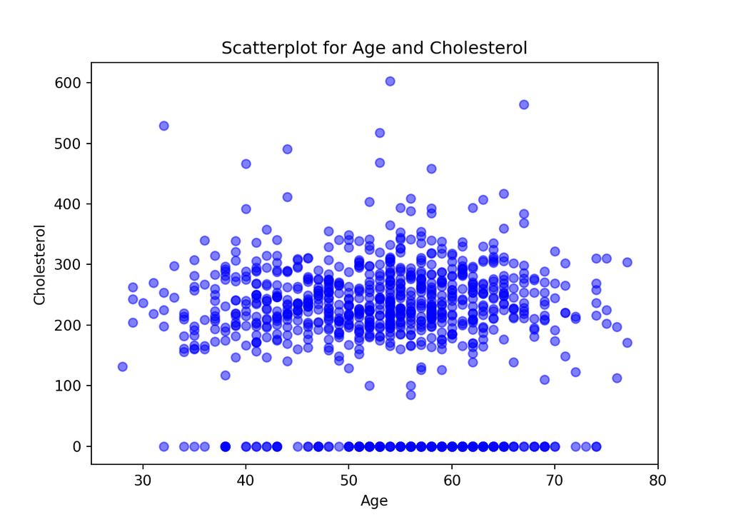

```python
plt.xlabel('Age')
plt.ylabel('Cholesterol')
plt.title('Scatterplot for Age and Cholesterol')
plt.show()
```

**According to the scatter plot above, we are able to see that the level of cholesterol is highest for people aged between 50 and 60.**

### Concluding Remarks

**Based on the analysis we have done above, we can conclude that the result of heart disease is from various aspects. We cannot strictly predict the result from each single variable. However, we can still discover the genral correlation between each clinical index and the final result as an reference in living habits.**